# Positions in the United Rugby Championships: Understanding Indicator Variables | SOLUTIONS

Unlike other sports, which often have a “look”, rugby is unique in that it is intended to be accessible to players of various shapes and sizes. Different positions have distinct expectations and therefore are best suited to people with distinct physiques. This makes the height and weight data interesting to explore, especially with regard to position.

Props are relied on for strength and power and are often used like battering rams against the other team. The hooker is responsible for more technical game play, like winning the ball back and restarting play. Locks are the main source of power on the team and are usually tall and strong in their legs. The scrum-half is responsible for covering many different parts of the pitch and is also useful in attacks, meaning they must be very fast. The fly-half is usually the most important player on the pitch and defines the strategy of the team, making their role more tactical than strength-based. The fullback is the furthest back player on the pitch and needs to be quick to be the last line of defense against attacks.

```r
library(tidyverse)
library(ggplot2) ## for graphing
library(dplyr) ## for data manipulation

players <- read.csv("URCpositions.csv")
```

### Run the following code chunk. The scatterplot shows height of players being used as a predictor for weight. The graph has a separate line for each position.

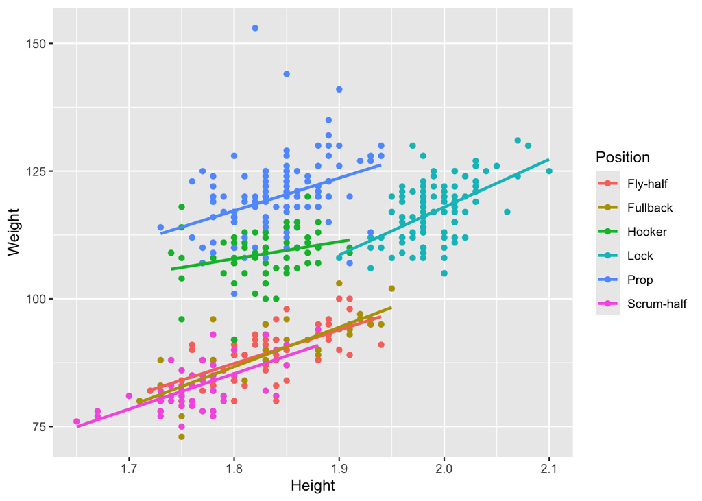

```r
ggplot(players, aes(x = Height, y = Weight, colour = Position)) +
  geom_point() +
  geom_smooth(method = "lm", se = FALSE)
```

### In the graph, we can see that the lines of best fit for some positions have very different intercepts than others. To make a model that accounts for this, we will have to use indicator variables.

### There are 6 positions present in the data set, so we need 5 indicator variables. The code block below defines 4 of them: the indicators for prop, hooker, lock, and scrum-half. For each of them, the observation will be assigned a `1` if that is the player’s position, and a `0` otherwise.

```r
players <- players |> mutate(prop_ind = if_else(Position == "Prop", 1, 0),
                                     hook_ind = if_else(Position == "Hooker", 1, 0),
                                     lock_ind = if_else(Position == "Lock", 1, 0),
                                     scrum_ind = if_else(Position == "Scrum-half", 1, 0))
```

### 1. Define the 5th indicator variable (for `Fullback`).

```r
players <- players |> mutate(full_ind = if_else(Position == "Fullback", 1, 0))
```

### 2. Fit a model that uses `Height` as a predictor for `Weight` and includes all of the indicator variables. Print a summary of the model.

```r
modPos = lm(Weight ~ Height + prop_ind + hook_ind + lock_ind + scrum_ind + full_ind, data = players)

summary(modPos)
```

```
Call:
lm(formula = Weight ~ Height + prop_ind + hook_ind + lock_ind +
    scrum_ind + full_ind, data = players)

Residuals:
    Min      1Q  Median      3Q     Max
-17.563  -3.189   0.110   3.042  34.571

Coefficients:
            Estimate Std. Error t value Pr(>|t|)
(Intercept) -35.4134    10.2381  -3.459 0.000594 ***
Height       68.1551     5.5820  12.210  < 2e-16 ***
prop_ind     29.8001     0.8312  35.853  < 2e-16 ***
hook_ind     19.5831     0.9482  20.652  < 2e-16 ***
lock_ind     16.8032     1.2402  13.549  < 2e-16 ***
scrum_ind    -1.9677     1.0184  -1.932 0.053976 .
full_ind     -0.2263     1.0837  -0.209 0.834719
---
Signif. codes:  0 '***' 0.001 '**' 0.01 '*' 0.05 '.' 0.1 ' ' 1

Residual standard error: 5.23 on 447 degrees of freedom
Multiple R-squared:  0.8919,    Adjusted R-squared:  0.8905
F-statistic:   615 on 6 and 447 DF,  p-value: < 2.2e-16
```

### 4. Is it helpful to have indicator variables for ALL of the different positions in this dataset? Why or why not?

Answers may vary. Students should point out that according to both the scatterplot and the model summary, the scrum-half, fly-half, and fullback positions have very similar lines and most likely do not need separate indicator variables.

### Regardless of your answer to number 4, we will look at a version of the model without the indicator variables for scrum-half and fullback. We will instead leave them grouped in with the fly-halves in a group we will call the Backs. Run the following code chunk to see a scatterplot reflecting this model.

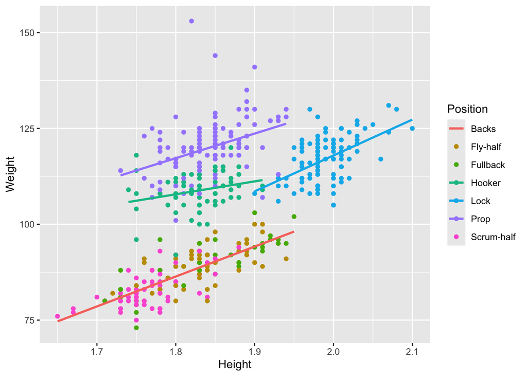

```r
players <- players |> mutate(Position2 = if_else(Position %in% c("Fullback", "Scrum-half", "Fly-half"), "Backs", Position))

ggplot(players, aes(x = Height, y = Weight)) +
  geom_point(aes(colour = Position)) +
  geom_smooth(aes(colour = Position2), method = "lm", se = FALSE)
```

### 5. Refit the model without the indicator variables for scrum-half and fullback. Print a summary of the model.

```r
modPos2 = lm(Weight ~ Height + prop_ind + hook_ind + lock_ind, data = players)

summary(modPos2)
```

```
Call:
lm(formula = Weight ~ Height + prop_ind + hook_ind + lock_ind,
    data = players)

Residuals:
    Min      1Q  Median      3Q     Max
-17.851  -3.040   0.103   3.021  34.672

Coefficients:
            Estimate Std. Error t value Pr(>|t|)
(Intercept) -44.0443     9.3385  -4.716 3.21e-06 ***
Height       72.4778     5.1600  14.046  < 2e-16 ***
prop_ind     30.4630     0.6495  46.900  < 2e-16 ***
hook_ind     20.3115     0.7837  25.916  < 2e-16 ***
lock_ind     16.8294     1.1515  14.615  < 2e-16 ***
---
Signif. codes:  0 '***' 0.001 '**' 0.01 '*' 0.05 '.' 0.1 ' ' 1

Residual standard error: 5.243 on 449 degrees of freedom
Multiple R-squared:  0.8909,    Adjusted R-squared:   0.89
F-statistic:   917 on 4 and 449 DF,  p-value: < 2.2e-16
```

### 6. What does the t-test on the prop indicator variable tell us?

There is significant evidence (t = 46.900, p ~= 0) that there is a difference between the starting weights for players who are in the prop position as compared to players who play in the fly-half, fullback, or scrum-half positions.

### 7. Interpret, in context, the coefficient for one of the indicator variables.

Answers will vary. One example: On average, a player in the hooker position will be 20.31 kg heavier than a back player of the same height.